# xwMOOC 고생대 프로젝트

위키 무작위 이미지

# 1 딥러닝의 시작 [^1]

이미지를 가지고 딥러닝을 시작할 경우 가장 먼저 딥러닝에 활용할 다양한 이미지를 얻는 것으로부터 시작된다. 사진 정보는 과거 [플리커(flickr)](https://www.flickr.com/), 최근에 [인스타그램(instagram)](https://www.instagram.com/?hl=ko) 등 진화하고 있지만, 모두 상업성을 염두에 두고 있어 각별한 주의가 필요하다. 상대적으로 위키백과로 유명한 위키재단에서 제공하는 API를 통해 이미지를 얻는 것이 유용할 경우가 많다.

# 2 랜덤 무작위 이미지 가져오기 [^2]

위키에서 제공하는 [Wikimedia API](https://www.mediawiki.org/wiki/API:Main_page)를 통해 방대한 위키에서 제공하는 이미지 정보에 접근이 가능하다. 특히, R 코드로 random_image.R이 공개되어 있어 코드를 재사용해서 랜덤 무작위 이미지를 가져온다.

```r
# 0. 환경설정 -----
library(tidyverse)
library(magick)
library(httr)
library(tools)

random_image <- function() {
  ## Return the URL random image in Wikimedia Commons
  random_query <- paste0("https://commons.wikimedia.org/w/api.php?",
                         "action=query",
                         "&generator=random", # get a random page
                         "&grnlimit=1",       # return 1 page
                         "&grnnamespace=6",   # category: File
                         "&prop=imageinfo",
                         "&iiprop=url|size|extmetadata",
                         "&iiurlheight=1080",  # limit images height (sometimes)
                         "&format=json&formatversion=2")
  random_response <- POST(random_query)
  output <- content(random_response)
  url <- output$query$pages[[1]]$imageinfo[[1]]$url
  ext <- tolower(file_ext(url))
  w <- output$query$pages[[1]]$imageinfo[[1]]$width
  h <- output$query$pages[[1]]$imageinfo[[1]]$height
  size <- output$query$pages[[1]]$imageinfo[[1]]$size
  desc <- output$query$pages[[1]]$imageinfo[[1]]$extmetadata$ImageDescription$value
  if(w<50 || h<50) stop("Image too small")
  if(size > 4000000) stop("Image too large")
  if(!(ext %in% c("jpg","jpeg","png","gif","bmp"))) stop(paste("invalid image type:",ext))
  attr(url, "dims") <- c(w=w,h=h)
  attr(url, "desc") <- desc
  url
}
```

# 3 하나가 아닌 다수 이미지

이미지를 다수 가져온다. 명심해야 되는 사실은 이미지가 정형화 되어 있지 않아 모양과 크기가 제각기라 얖서 정한 기준에 맞는 것만 가져온다. 파일 형식도 마찬가지다.

```r
# 1. 데이터 -----
## 1.1. 이미지 데이터 위키에서 가져오기 -----
wiki_image_list <- vector("list", length=20)

for(i in 1:length(wiki_image_list)) {
  tryCatch({
    wiki_image_list[[i]] <- random_image()
  }, error = function(e) {})
}

wiki_image_list <- plyr::compact(wiki_image_list)

listviewer::jsonedit(wiki_image_list)
```

[interactive chart not shown]

# 4 리스트 → 데이터프레임

무작위로 가져온 이미지 데이터를 이미지 처리를 위해서 데이터프레임으로 변환시킨다.

```r
## 1.2. 리스트 --> 데이터프레임 변환 -----
wiki_image_df <- tibble(
  desc = map_chr(wiki_image_list, attr, which="desc"),
  dims = map(wiki_image_list, attr, which="dims"),
  url  = wiki_image_list %>% unlist
)

wiki_image_df <- wiki_image_df %>%
  mutate(dims = map(dims, enframe, name="dim")) %>%
  unnest(dims) %>%
  spread(dim, value)

wiki_image_df %>%
  select(h, w, desc, url) %>%
  DT::datatable()
```

[output not shown]

[output cut: 3 more lines]

# 5 이미지 처리

`image_read()` 함수를 통해서 **URL**만 있다면 바로 이미지 처리가 가능하다. 가져온 이미지만 엄지손톱 그림(thumbnail) 형태로 작게 해서 제대로 준비가 되었는지 시각적으로 확인한다.

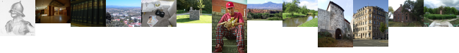

```r
# 2. 매직 시각화 -----
## 2.1. URL --> 이미지 변환
magick_image_list <- vector("list", length=nrow(wiki_image_df))

for(i in 1:nrow(wiki_image_df)) {
  magick_image_list[[i]] <- image_read(wiki_image_df$url[i])
}
## 크기 300x px 통일
magick_image_list <- map(magick_image_list, image_scale, geometry="300x")

map(magick_image_list, image_scale, geometry="50x") %>%
  image_join() %>%
  image_append()
```

# 6 환영도장 찍기

위키에서 무작위로 뽑기한 이미지가 R 이미지 처리 분야로 넘어왔다는 것을 환영하는 의미에서 모든 이미지에 R 로고를 찍고 이를 애니메이션 형태로 제작한다.

[figure not shown]

```r
## R 로고 가져오기
r_logo <- image_read("https://jeroen.github.io/images/Rlogo.png") %>%
  image_scale("100x")

## 모든 이미지에 R 로고 삽입
magick_image_list <- map(magick_image_list, function(x) image_composite(x, r_logo, offset="+200+110"))

magick_image_df <- image_join(magick_image_list)

image_animate(magick_image_df, fps=0.5, dispose = "previous")
```

[^1]: [Revolutions - Generate image captions with the Computer Vision API](http://blog.revolutionanalytics.com/2018/03/computer-vision-api.html)
[^2]: random_image.R